# Lecture Script - Repeated Measures

## Relaxing the Constant Variance Assumption

A plot of the data highlighting the pharmacokinetics of Indomethacin is shown below.

```r
indometh <- read_csv("Indometh.csv")
```

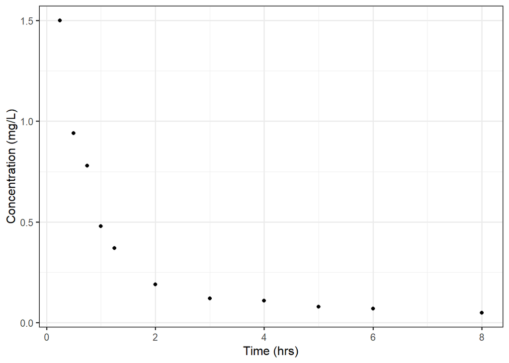

```r
ggplot(data = indometh,
       mapping = aes(y = conc, x = time)) +
  geom_point() +
  labs(y = "Concentration (mg/L)",
       x = "Time (hrs)")
```

We fit the bi-exponential model to capture the two-compartment open model suggested by scientists. We then obtain residuals to assess the conditions regarding the model.

```r
fit1.indometh <- nls(conc ~ SSbiexp(time, A1, lrc1, A2, lrc2), data = indometh)

aug.indometh <- augment(fit1.indometh, data = indometh)
```

The residual graphics are created much like we have done in the past. The residual-vs-fits graphic can be used to assess the mean-0 and constant variance conditions.

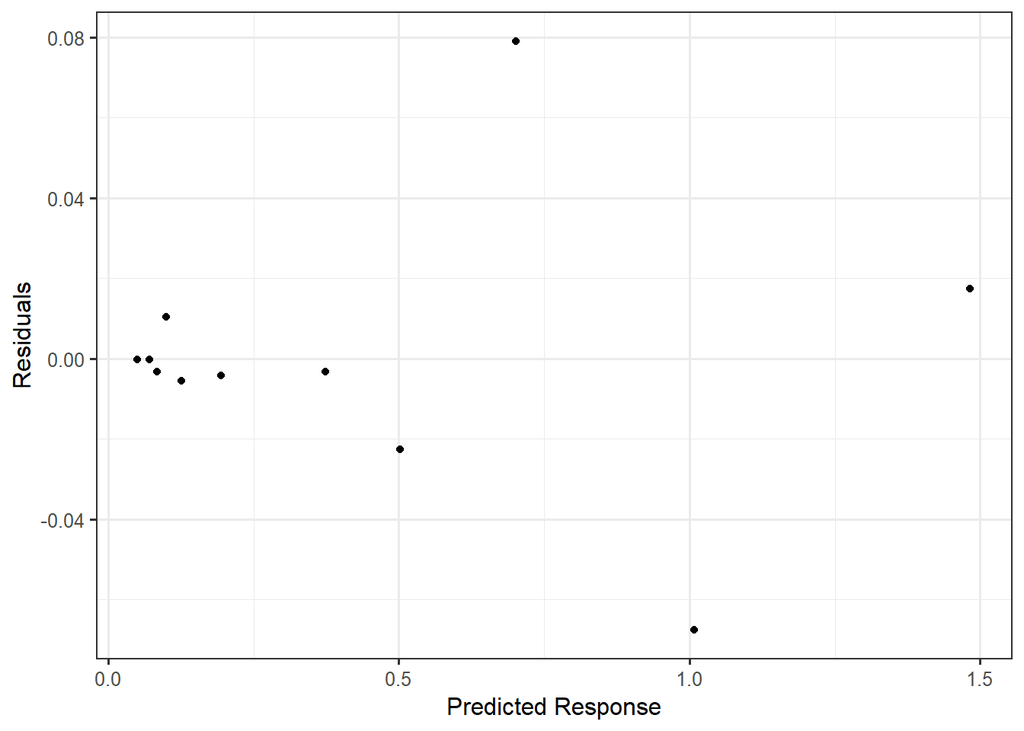

```r
ggplot(data = aug.indometh,
       mapping = aes(y = .resid, x = .fitted)) +
  geom_point() +
  labs(y = "Residuals",
       x = "Predicted Response")
```

It seems clear here that the constant variance condition is violated. Visually, we see this in the fit below.

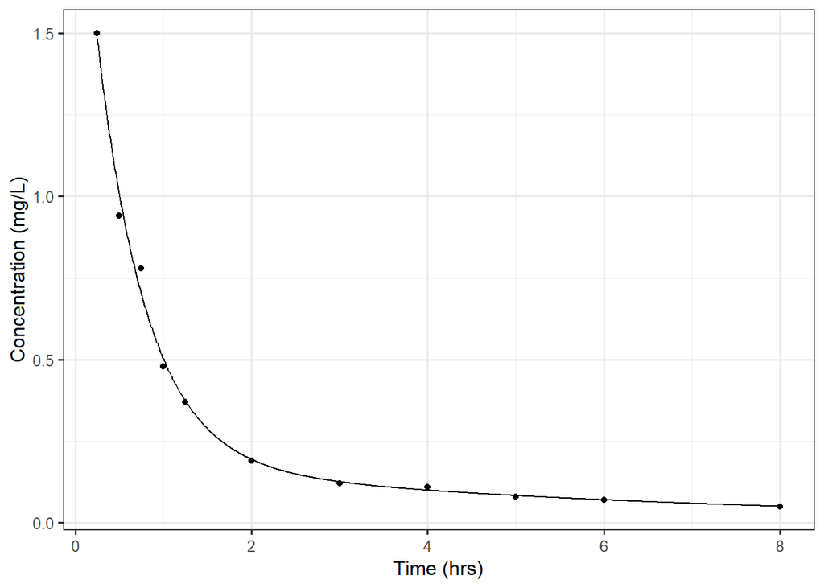

Below are the confidence intervals which assumed constant variance based on large-sample theory (default in `nls()`):

```
             2.5       97.5
A1    1.81387193  2.2446829
lrc1  0.33507262  0.8237047
A2   -0.02527641  0.4083713
lrc2 -3.33052779 -0.2450421
```

We can obtain the confidence intervals via a wild bootstrap using the `WildBoot()` function, which has an interface similar to the `Boot()` function. *Note that this code is unique to this course.*

```r
boot.indometh <- WildBoot(fit1.indometh)
```

```
 Number of bootstraps was 987 out of 999 attempted
```

```r
confint(boot.indometh, type = "perc", level = 0.95)
```

```
Bootstrap percent confidence intervals

          2.5 %     97.5 %
A1    1.9288760  2.1694570
lrc1  0.3909211  0.9388138
A2    0.1078278  0.4084796
lrc2 -2.6376356 -1.0904976
```

In particular, note that the confidence interval for `A2` is quite a bit different.

## Logistic Regression

Consider the following plot summarizing the type of nest constructed and the length of a bird’s body. As an aside, this is not the best visualization, but is a naive starting point given the material discussed thus far in the course.

```r
birds <- read_csv("Birdnest.csv")
```

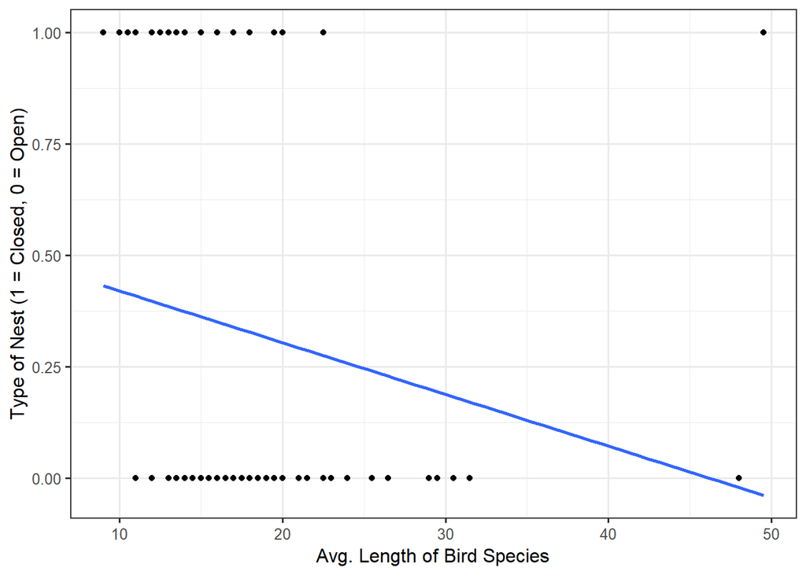

The logistic model is fit using the `glm()` function. Note that the response must be a numeric 0/1 variable, with 1 indicating the group you want to model. For our case, we are modeling the probability that a bird builds a closed nest. The `family="binomial"` option specifies the logistic part of the model. Variables enter the model (in this case only length) as they do in a linear model.

```r
fit.birds <- glm(Closed ~ Length, family="binomial", data = birds)

tidy(fit.birds, conf.int = TRUE)
```

```
# A tibble: 2 x 7
  term        estimate std.error statistic p.value conf.low conf.high
  <chr>          <dbl>     <dbl>     <dbl>   <dbl>    <dbl>     <dbl>
1 (Intercept)   0.457     0.753      0.607   0.544   -0.921   2.04
2 Length       -0.0677    0.0425    -1.59    0.112   -0.161   0.00673
```

```r
glance(fit.birds)
```

```
# A tibble: 1 x 7
  null.deviance df.null logLik   AIC   BIC deviance df.residual
          <dbl>   <int>  <dbl> <dbl> <dbl>    <dbl>       <int>
1          120.      94  -58.4  121.  126.     117.          93
```

In order to compute the confidence intervals and estimates on the odds-ration scale, we can use the `exp()` function.

```r
tidy(fit.birds, conf.int = TRUE) %>%
  mutate(estimate = exp(estimate),
         conf.low = exp(conf.low),
         conf.high = exp(conf.high))
```

```
# A tibble: 2 x 7
  term        estimate std.error statistic p.value conf.low conf.high
  <chr>          <dbl>     <dbl>     <dbl>   <dbl>    <dbl>     <dbl>
1 (Intercept)    1.58     0.753      0.607   0.544    0.398      7.71
2 Length         0.935    0.0425    -1.59    0.112    0.852      1.01
```

## Model Selection

We can use a variety of measures to quantify the quality of the model fit — how well the data adheres to the model being posited. Consider the bacteria study we examined previously. A Michaelis-Menten model was originally suggested, which we fit previously and which is summarized below.

```r
fit.bacteria <- nls(Rate ~ SSmicmen(Substrate, Vm, K), data = bact)

tidy(fit.bacteria)
```

```
# A tibble: 2 x 5
  term  estimate std.error statistic  p.value
  <chr>    <dbl>     <dbl>     <dbl>    <dbl>
1 Vm        43.0      4.62      9.31 0.000740
2 K         13.3      3.23      4.12 0.0147
```

```r
glance(fit.bacteria)
```

```
# A tibble: 1 x 8
  sigma isConv     finTol logLik   AIC   BIC deviance df.residual
  <dbl> <lgl>       <dbl>  <dbl> <dbl> <dbl>    <dbl>       <int>
1  1.55 TRUE   0.00000565  -9.92  25.8  25.2     9.59           4
```

Suppose a different research team believes the behavior would be better characterized by an asymptotic growth model. This is fit and summarized below.

```r
fit2.bacteria <- nls(Rate ~ SSasympOrig(Substrate, Asym, lrc), data = bact)

tidy(fit2.bacteria)
```

```
# A tibble: 2 x 5
  term  estimate std.error statistic  p.value
  <chr>    <dbl>     <dbl>     <dbl>    <dbl>
1 Asym     31.8      2.92       10.9 0.000403
2 lrc      -2.44     0.215     -11.3 0.000347
```

```r
glance(fit2.bacteria)
```

```
# A tibble: 1 x 8
  sigma isConv     finTol logLik   AIC   BIC deviance df.residual
  <dbl> <lgl>       <dbl>  <dbl> <dbl> <dbl>    <dbl>       <int>
1  1.93 TRUE   0.00000162  -11.2  28.5  27.8     14.8           4
```

The following graphic visually compares the two models to support what we observe from the fit criteria above.

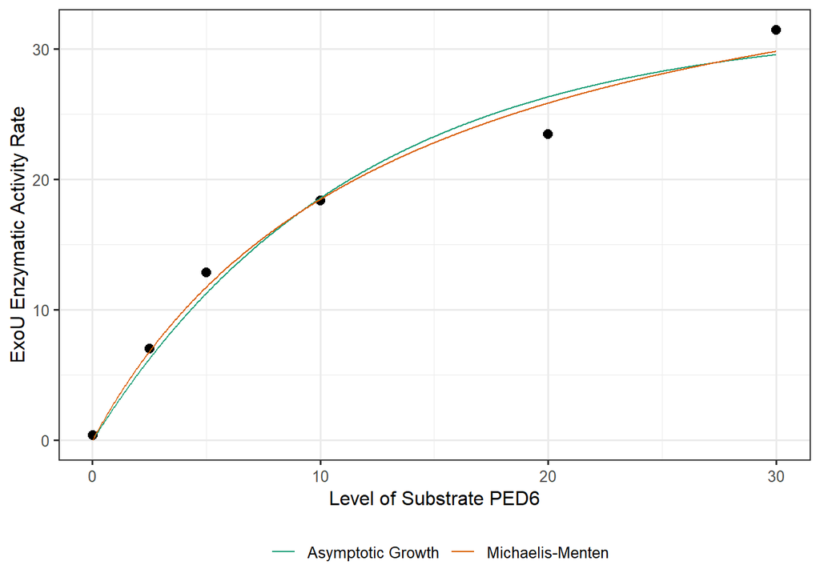